# chapter 10 demo clustering

*Agglomerative hierarchical clustering*

- Agglomerative clustering (bottom-up)
- Starts with as each sample in its own cluster
- Joins the two most similar clusters
- Then, joins next two most similar clusters

-Continues until all samples are in one cluster

Given the sample correlation matrix

```
##                 JPMorgan Citybank WellsFargo RoyalDutchShell ExxonMobil
## JPMorgan            1.00     0.63       0.51            0.12       0.16
## Citybank            0.63     1.00       0.57            0.32       0.21
## WellsFargo          0.51     0.57       1.00            0.18       0.15
## RoyalDutchShell     0.12     0.32       0.18            1.00       0.68
## ExxonMobil          0.16     0.21       0.15            0.68       1.00
```

-When the sample correlations are used as similarity measures,

- Variables with large negative correlation are regarded as very dissimilar. Variables with large positive correlation are regarded as very similar.

-Base on the fact that **“hclust”** function only reads a dissimilarity structure, hence, a transformation required to cluster the the stocks using these hierarchical procedures is **1-correlation** as follow.

```r
# construct the similarity measurement given the correlation matrix: 1-cor
stock_dis = as.dist(1-stock_col )
stock_dis
```

```
##                 JPMorgan Citybank WellsFargo RoyalDutchShell
## Citybank            0.37
## WellsFargo          0.49     0.43
## RoyalDutchShell     0.88     0.68       0.82
## ExxonMobil          0.84     0.79       0.85            0.32
```

**Single linkage**

- The inputs to a single linkage algorithm can be distances or similarities between pairs of objects. Groups are formed from the individual entities by merging nearest neighbors.

-We find the smallest distance in $D=\{d_{ik} \}$ and merge the corresponding objects say $U$ and $V$, to get the cluster $(UV)$.

- The distance between $(UV)$ and any other cluster $W$ are computed by $d_{(UV)W} = \text{min} \{d_{UW},d_{VW} \}$

where the quantities $d_{UW}$ and $d_{VW}$ are the distances between the nearest neighbors of clusters $U$ and $W$ and clusters $V$ and $W$, respectively.

$$\begin{array}{lc}
\mbox{} & \begin{array}{cc} 1 && 2 && 3 && 4
&& 5\end{array} \\
\begin{array}{c} 1 \\ 2 \\ 3 \\ 4 \\ 5 \end{array} &
\left[\begin{array}{cc}
1 \\
0.63 & 1 \\
0.51 & 0.57 & 1 \\
0.12 & 0.32 & 0.18 & 1 \\
0.16 & 0.21 & 0.15 & \underline{0.68} &
1 \end{array}\right]
\end{array}
\Rightarrow \begin{array}{lc}
\mbox{} & \begin{array}{cc} 45 && 1 && 2 &&
3 \end{array} \\
\begin{array}{c} 45 \\ 1 \\ 2 \\ 3\end{array} &
\left[\begin{array}{cc}
1 \\
0.16 & 1 \\
0.32 & \underline{0.63} & 1 \\
0.18 & 0.51 & 0.57 & 1 \end{array}\right]
\end{array}
\Rightarrow \begin{array}{lc}
\mbox{} & \begin{array}{cc} 45 && 12 && 3
\end{array} \\
\begin{array}{c} 45 \\ 12 \\ 3 \end{array} &
\left[\begin{array}{cc}
1 \\
0.32 & 1 \\
0.18 & \underline{0.57} & 1 \end{array}\right]
\end{array}
\Rightarrow \begin{array}{lc}
\mbox{} & \begin{array}{cc} 45 && 123 \end{array} \\
\begin{array}{c} 45 \\ 123 \end{array} &
\left[\begin{array}{cc}
1 \\
\underline{0.32} & 1 \end{array}\right]
\end{array}$$

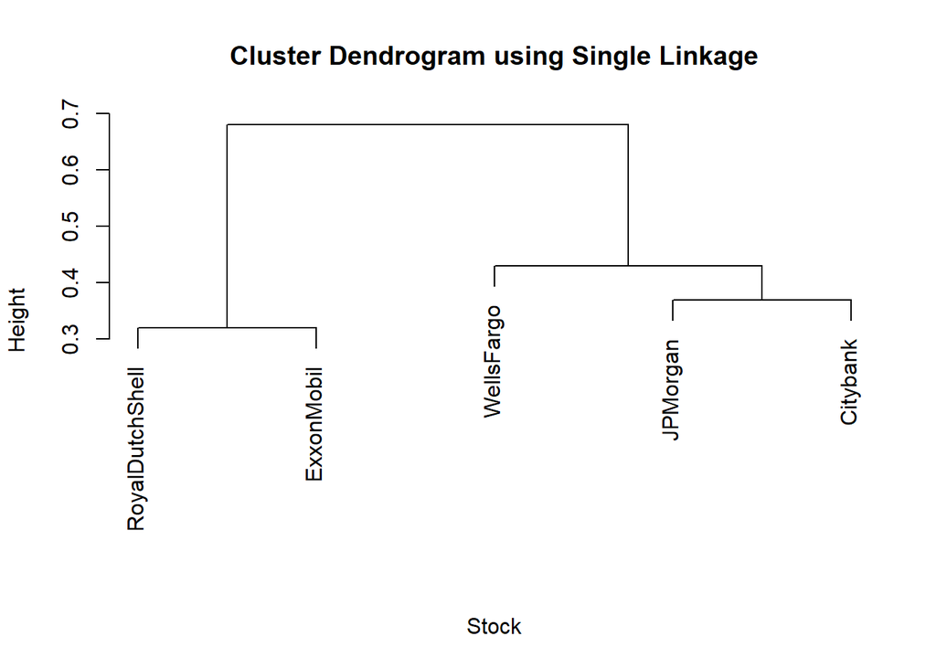

```r
# single linkage
single_linkage_stcok = hclust(stock_dis, method = "single")
plot(single_linkage_stcok,  sub="",xlab="Stock", main="Cluster Dendrogram using Single Linkage")
```

**Complete linkage**

- Complete linkage clustering proceeds in much the same manner as single linkage clustering. In complete linkage at each stage, the distance between clusters is determined by the distance between the two elements one from each cluster, that are most distance.

-First we find the minimum entery in $D=\{d_{ik} \}$ and merging the corresponding objects, say $U$ and $V$, to get the cluster $(UV)$.

-The distance between $(UV)$ and any other cluster $W$ are computed by $d_{(UV)W} = \text{max} \{d_{UW},d_{VW} \}$

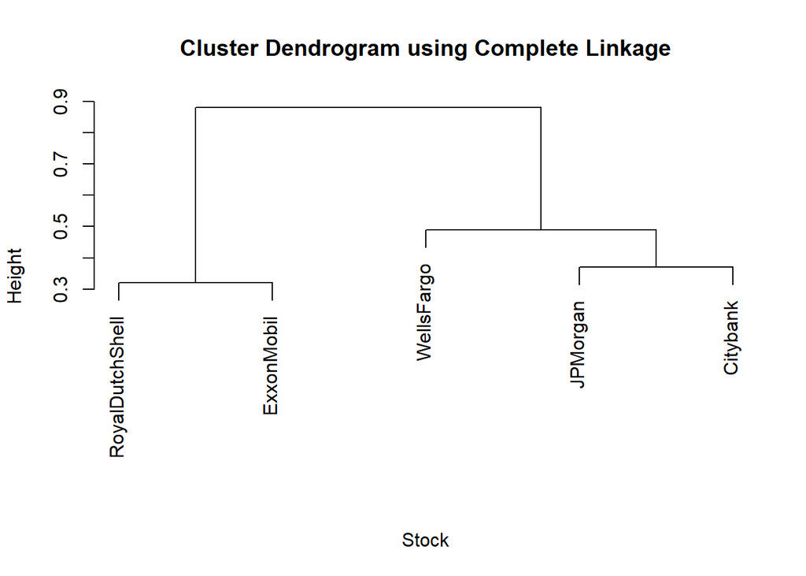

```r
# complete linkage hierarchical procedure
complete_linkage_stock = hclust(stock_dis, method = "complete")
plot(complete_linkage_stock,  sub="",xlab="Stock", main="Cluster Dendrogram using Complete Linkage")
```

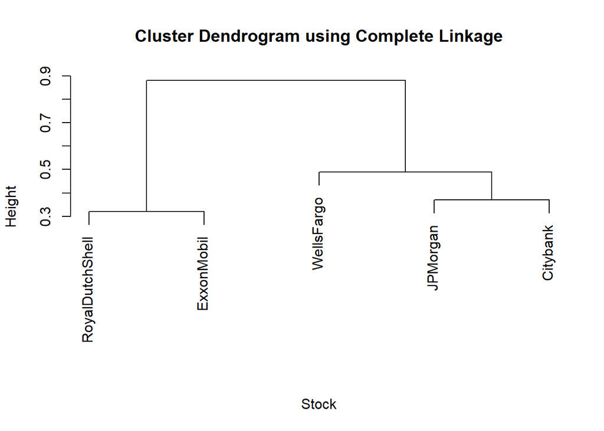

```r
# avaerage linkage hierarchical procedure
average_linkage_stock = hclust(stock_dis, method = "average")
plot(complete_linkage_stock,  sub="",xlab="Stock", main="Cluster Dendrogram using Complete Linkage")
```

*Reading the new dataset*

```r
data = read.table('T1-9.dat', header = F)
head(data, 10)
```

```
##     V1    V2    V3    V4   V5   V6   V7     V8
## 1  ARG 11.57 22.94 52.50 2.05 4.25 9.19 150.32
## 2  AUS 11.12 22.23 48.63 1.98 4.02 8.63 143.51
## 3  AUT 11.15 22.70 50.62 1.94 4.05 8.78 154.35
## 4  BEL 11.14 22.48 51.45 1.97 4.08 8.82 143.05
## 5  BER 11.46 23.05 53.30 2.07 4.29 9.81 174.18
## 6  BRA 11.17 22.60 50.62 1.97 4.17 9.04 147.41
## 7  CAN 10.98 22.62 49.91 1.97 4.00 8.54 148.36
## 8  CHI 11.65 23.84 53.68 2.00 4.22 9.26 152.23
## 9  CHN 10.79 22.01 49.81 1.93 3.84 8.10 139.39
## 10 COL 11.31 22.92 49.64 2.04 4.34 9.37 155.19
```

```r
names = data[,1]
data = data[,-1]
rownames(data) = names
dim(data)
```

```
## [1] 54  7
```

-Calculate the Euclidean distances between pairs of countries

```r
dis = dist(data, method = 'euclidean',diag = T); #dis
```

*Cluster the countries using the sinlge linkage, complete linkage and Ward’s hierarchical procedures and then compare the results.*

**1. Single linkage**

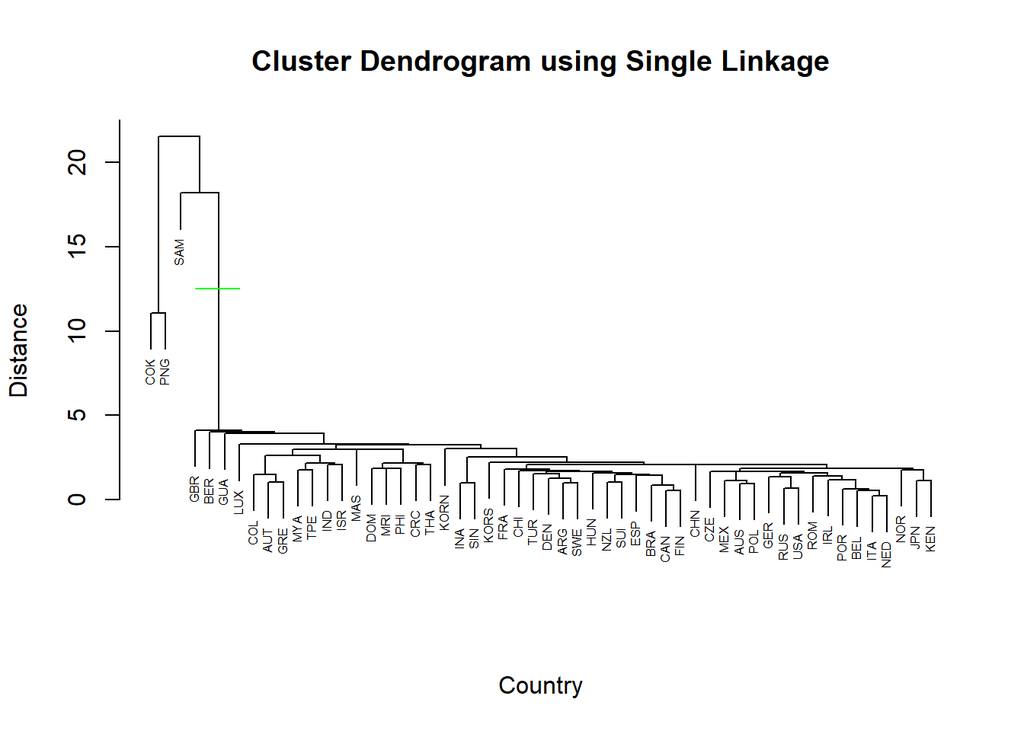

```r
# single linkage
single_linkage_track = hclust(dis, method = "single")
plot(single_linkage_track,  sub="",xlab="Country", main="Cluster Dendrogram using Single Linkage", cex=0.5, ylab="Distance")
segments(4,12.5,7,12.5, col="green")
```

**2. Complete linkage**

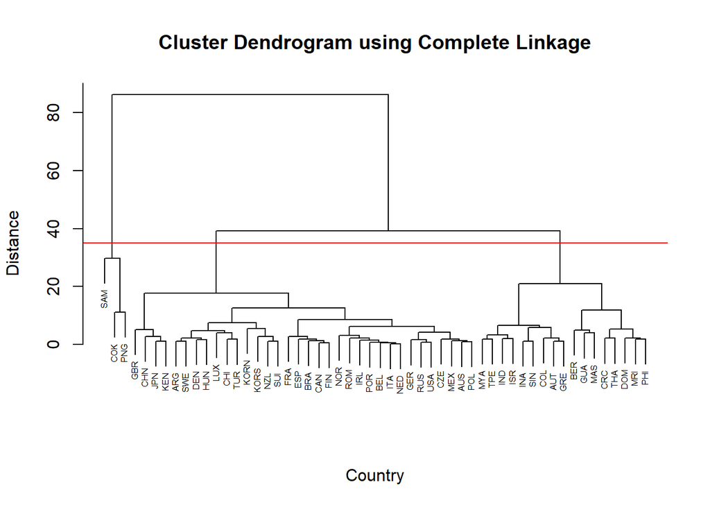

```r
# complete linkage
complete_linkage_track = hclust(dis,  method = "complete")
plot(complete_linkage_track,  sub="",xlab="Country", main="Cluster Dendrogram using Complete Linkage", cex=0.5, ylab="Distance")
abline(h=35, col="red")
```

**conslusion** In the cluster dendrogram using complete linkage procedure, three possible clusters are identified if we cut the dendrogram at distance 35 (red line).

Cluster 1: COK, PNG and SAM

Cluster 2 and 3: can be observed from the above dendrogram.

**3. Ward’s method**

-Ward considered hierarchical clustering procedures based on minimizing the “loss of information” from joining two groups.

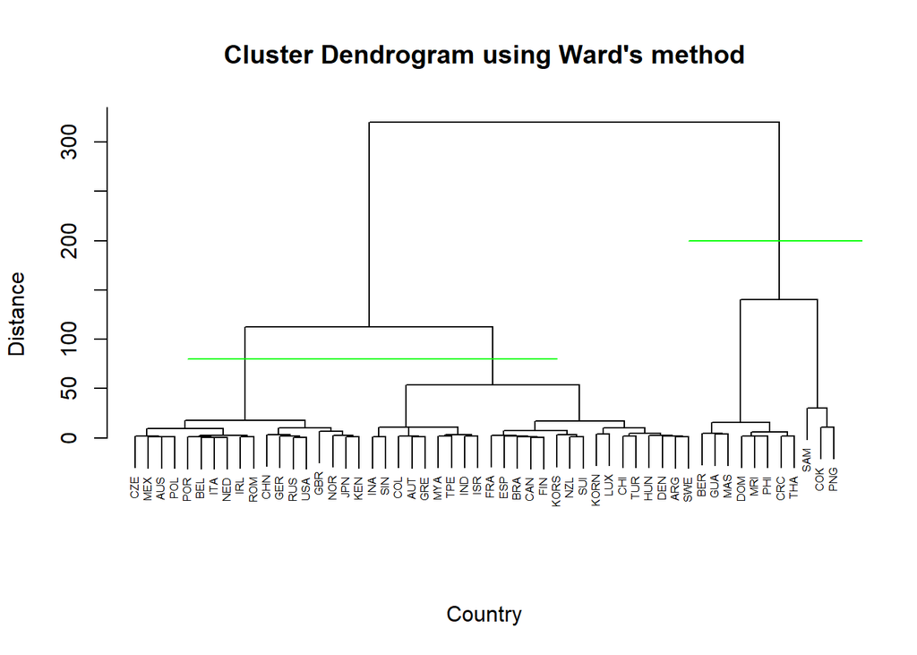

```r
# ward's hierarchical clustering method
ward_linkage = hclust(dis, method = "ward.D")
plot(ward_linkage,  sub="",xlab="Country", main="Cluster Dendrogram using Ward's method", cex=0.5, ylab="Distance")
segments(5,80,33,80, col="green")
segments(43,200,70,200, col="green")
```

**conslusion** In the above cluster dendrogram using Ward’s method, three clusters have been chose based on the cuts.

**4.Average linkage**

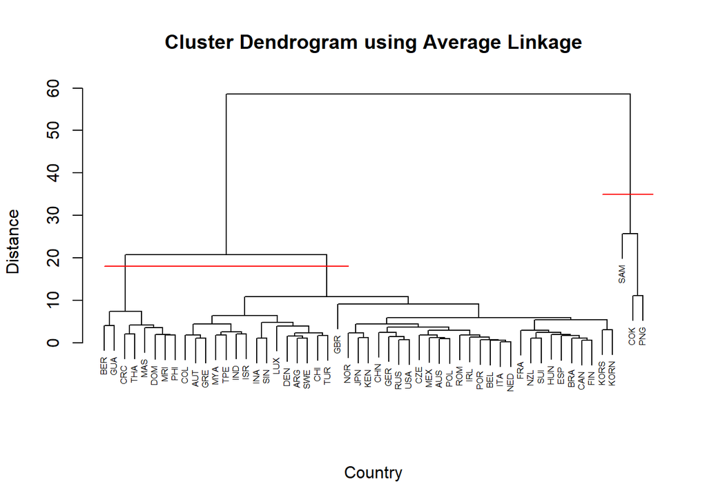

```r
# avg linkage hierarchical procedure
avg_linkage = hclust(dis, method = "average")
plot(avg_linkage,  sub="",xlab="Country", main="Cluster Dendrogram using Average Linkage", cex=0.5, ylab="Distance")
segments(1,18,25,18, col="red")
segments(50,35,55,35, col="red")
```

In the cluster dendrogram using average linkage, it coincides with the expectation that there are three clusters.

**Note :**The clusters are more apparent in the complete linkage dendrogram and, depending on the distance level, might have as few as 3 or 4 clusters or as many as 6 or 7 clusters.

*Non-hierarchical clustering method:*

*K-means Clustering*

- Clustering the countries into groups using k=3 and k=4 cluster.

**Bivariate cluster plots for K=3 and K=4**

```r
library(cluster)
# K-means clustering results for k=3 and k=4

# 3 cluster solution
km3 <- kmeans(data, 3)
# Clustering results
km3$cluster
```

```
##  ARG  AUS  AUT  BEL  BER  BRA  CAN  CHI  CHN  COL  COK  CRC  CZE  DEN  DOM  FIN
##    3    3    1    3    1    3    3    3    3    1    2    1    3    3    1    3
##  FRA  GER  GBR  GRE  GUA  HUN  INA  IND  IRL  ISR  ITA  JPN  KEN KORS KORN  LUX
##    3    3    3    3    1    3    1    1    3    1    3    3    3    3    3    3
##  MAS  MRI  MEX  MYA  NED  NZL  NOR  PNG  PHI  POL  POR  ROM  RUS  SAM  SIN  ESP
##    1    1    3    1    3    3    3    2    1    3    3    3    3    2    1    3
##  SWE  SUI  TPE  THA  TUR  USA
##    3    3    1    1    3    3
```

```r
# 4 cluster solution
km4 = kmeans(data, 4)
# Clustering results
km4$cluster
```

```
##  ARG  AUS  AUT  BEL  BER  BRA  CAN  CHI  CHN  COL  COK  CRC  CZE  DEN  DOM  FIN
##    3    4    3    4    1    4    4    3    4    3    2    1    4    3    1    4
##  FRA  GER  GBR  GRE  GUA  HUN  INA  IND  IRL  ISR  ITA  JPN  KEN KORS KORN  LUX
##    4    4    4    3    1    4    3    3    4    3    4    4    4    4    4    3
##  MAS  MRI  MEX  MYA  NED  NZL  NOR  PNG  PHI  POL  POR  ROM  RUS  SAM  SIN  ESP
##    1    1    4    3    4    4    4    2    1    4    4    4    4    2    3    4
##  SWE  SUI  TPE  THA  TUR  USA
##    3    4    3    1    3    4
```

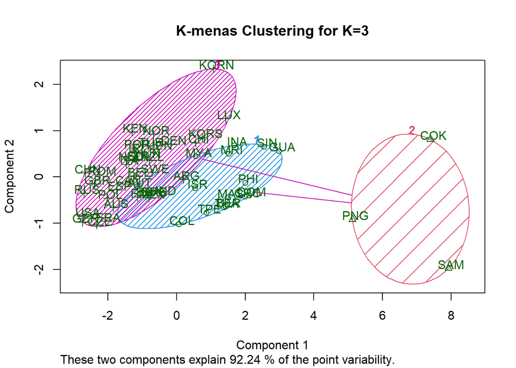

```r
# bivariate cluster plots for K=3 nad K=4
clusplot(data[,-1], km3$cluster, color = T, shade = T, labels = 2, main = "K-menas Clustering for K=3")
```

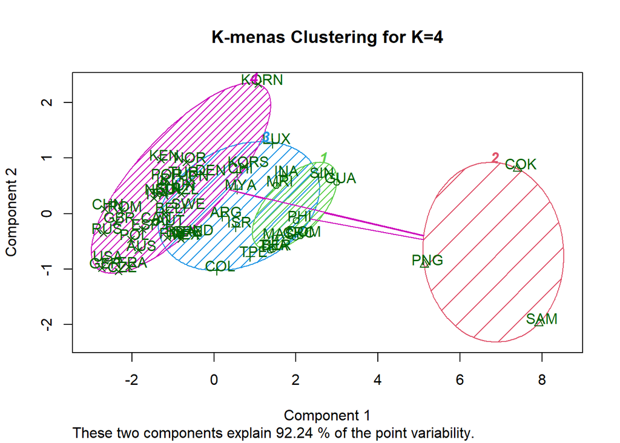

```r
clusplot(data[,-1], km4$cluster, color = T, shade = T, labels = 2, main = "K-menas Clustering for K=4")
```

**Silhouette plots for K=3 and K=4**

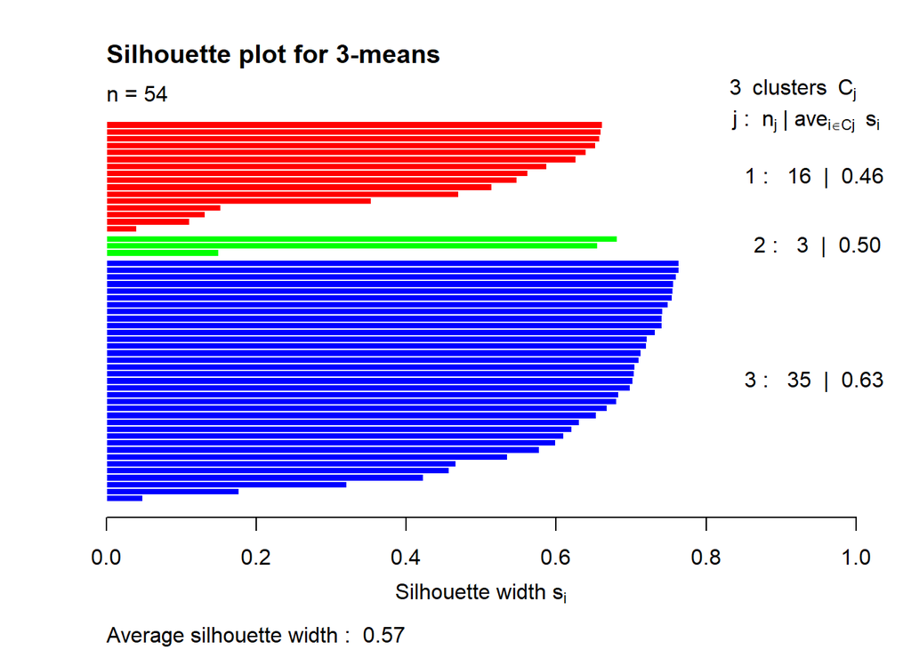

```r
# silhouette plots construction
# k=3
sil_3 = silhouette(km3$cluster, dis)
plot(sil_3, main = "Silhouette plot for 3-means",  col = c("red", "green", "blue"))
```

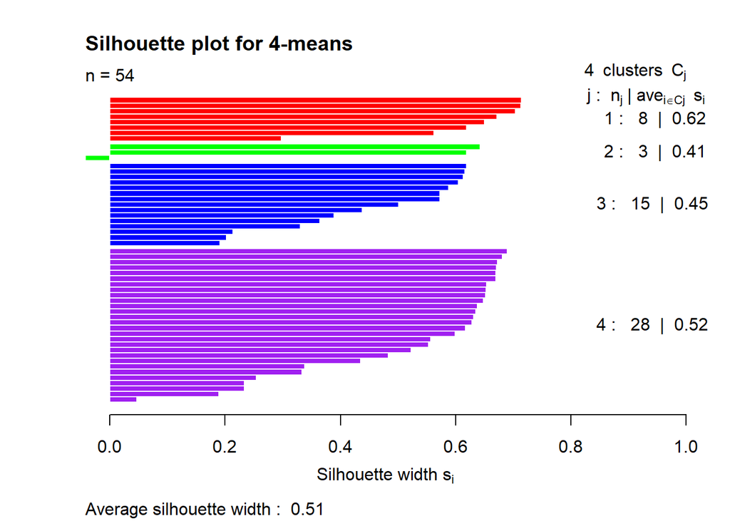

```r
# k=4
sil_4 = silhouette(km4$cluster, dis)
plot(sil_4, main = "Silhouette plot for 4-means",  col = c("red", "green", "blue", "purple"))
```

-By comparison of the average silhouette widths, it seems that K=3 is a desire number of clusters.

**conclusion**

Because the merge requirement of a single linkage technique is purely local, near overlap is more likely to cause confusion. Consider the case where a chain of points can be stretched across large distances without regarding to the overall shape of the emerging cluster (chaining effect).

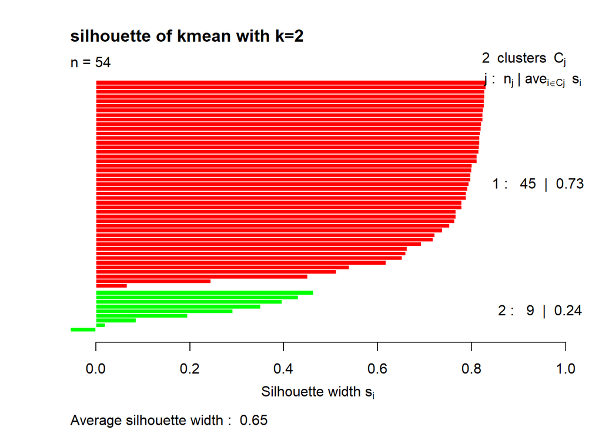

```r
####   silhouette value for Kmeans cluster =2
km2=kmeans(data,centers = 2)
Silkm2=silhouette(km2$cluster,dist(data))
plot(Silkm2,main = "silhouette of kmean with k=2",col = c("red", "green"))
```

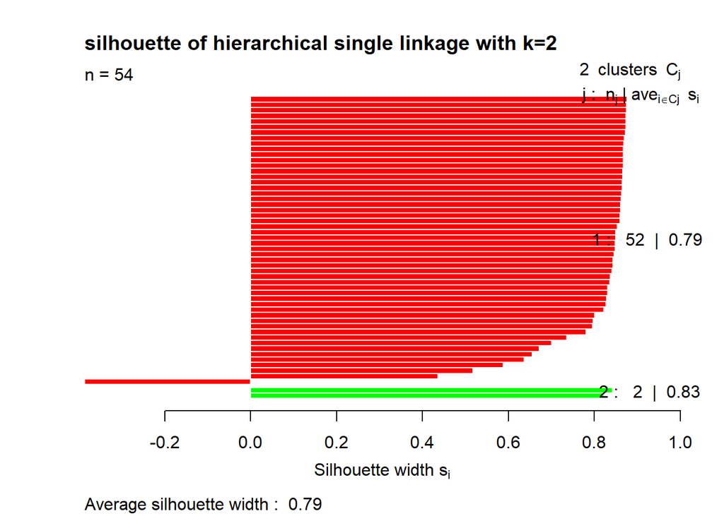

```r
####   silhouette value for Single linkage for k=2
Silhclsinglek2 <- silhouette(cutree(single_linkage_track,k=2),dist(data))
plot(Silhclsinglek2,main = "silhouette of hierarchical single linkage with k=2",col = c("red", "green"))
```

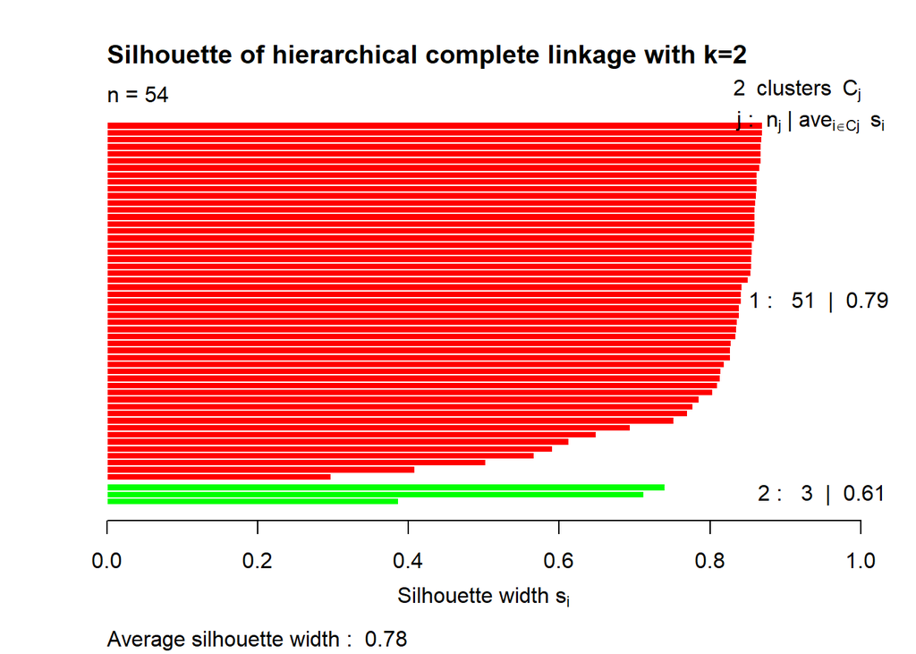

```r
####   silhouette value for complete linkage for k=2
Silhclcompletek2 <- silhouette(cutree(complete_linkage_track,k=2),dist(data))
plot(Silhclcompletek2,main = "Silhouette of hierarchical complete linkage with k=2",col = c("red", "green"))
```

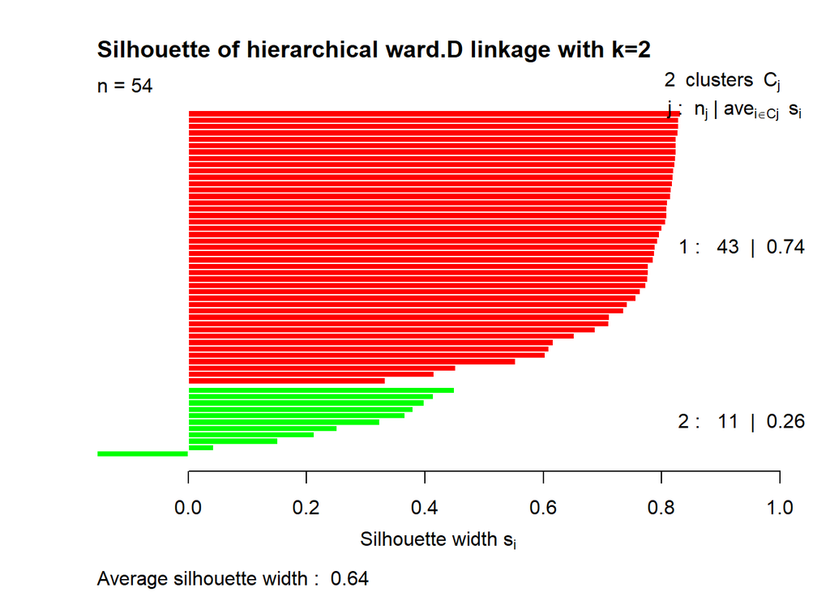

```r
####   silhouette value for ward linkage for k=2
SilhclwardDk2 <- silhouette(cutree(ward_linkage,k=2),dist(data))
plot(SilhclwardDk2,main = "Silhouette of hierarchical ward.D linkage with k=2",col = c("red", "green"))
```

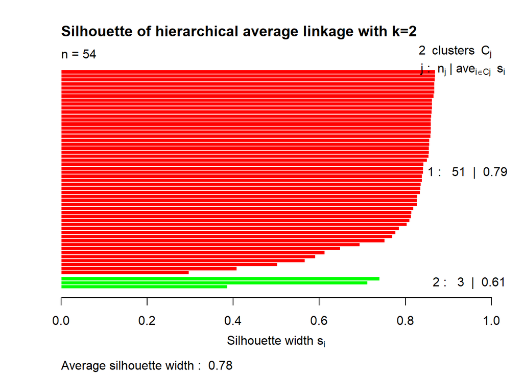

```r
####   silhouette value for Average linkage for k=2
SilhclwardDk2 <- silhouette(cutree(avg_linkage,k=2),dist(data))
plot(SilhclwardDk2,main = "Silhouette of hierarchical average linkage with k=2",col = c("red", "green"))
```

**K=3**

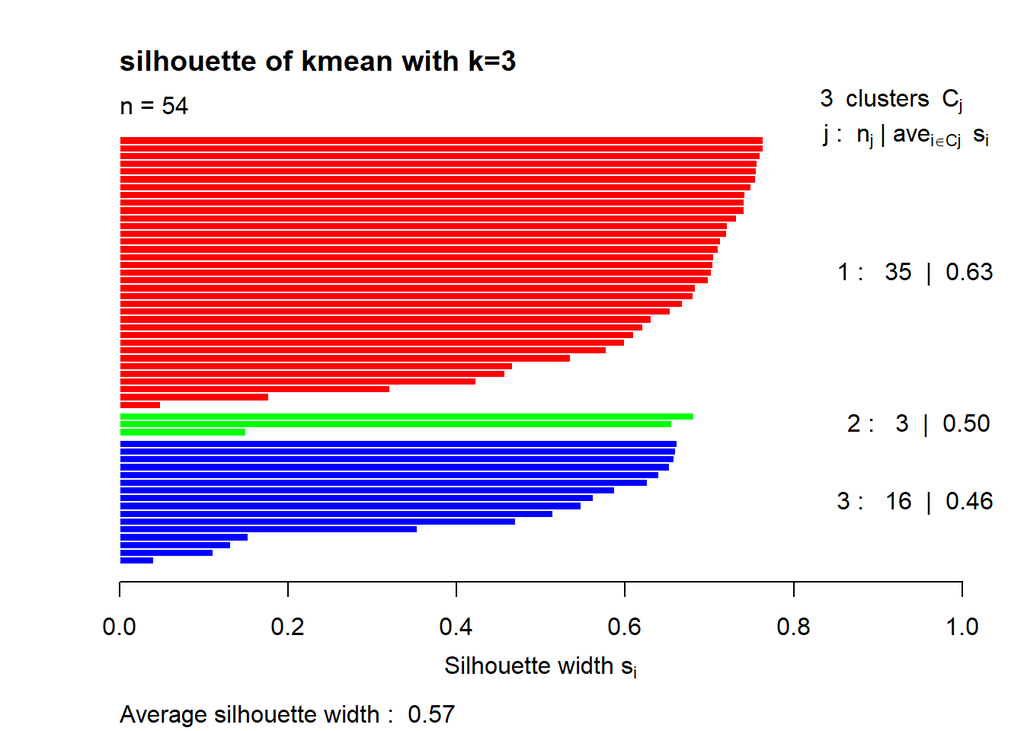

```r
####   silhouette value for Kmeans cluster =3
km3=kmeans(data,centers = 3)
Silkm3=silhouette(km3$cluster,dist(data))
plot(Silkm3,main = "silhouette of kmean with k=3",col = c("red", "green", "blue"))
```

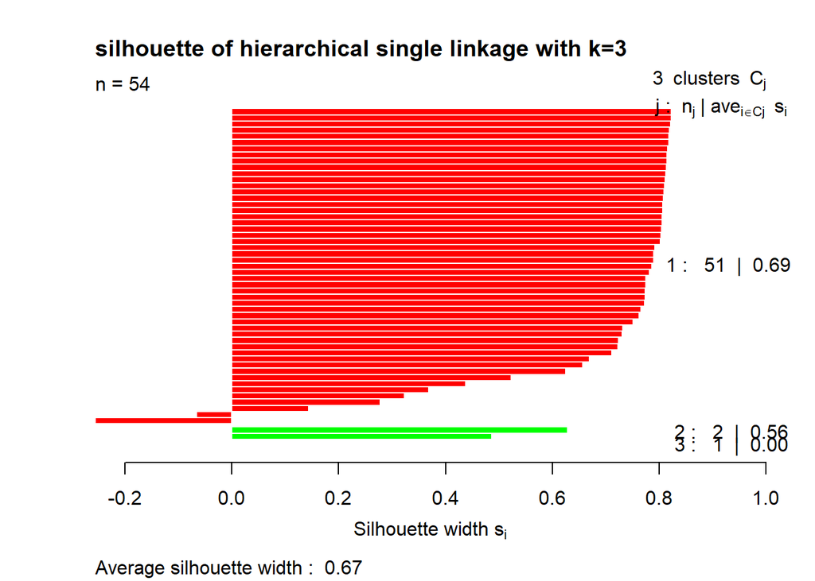

```r
####   silhouette value for Single linkage for k=3
Silhclsinglek2 <- silhouette(cutree(single_linkage_track,k=3),dist(data))
plot(Silhclsinglek2,main = "silhouette of hierarchical single linkage with k=3",col = c("red", "green","blue"))
```

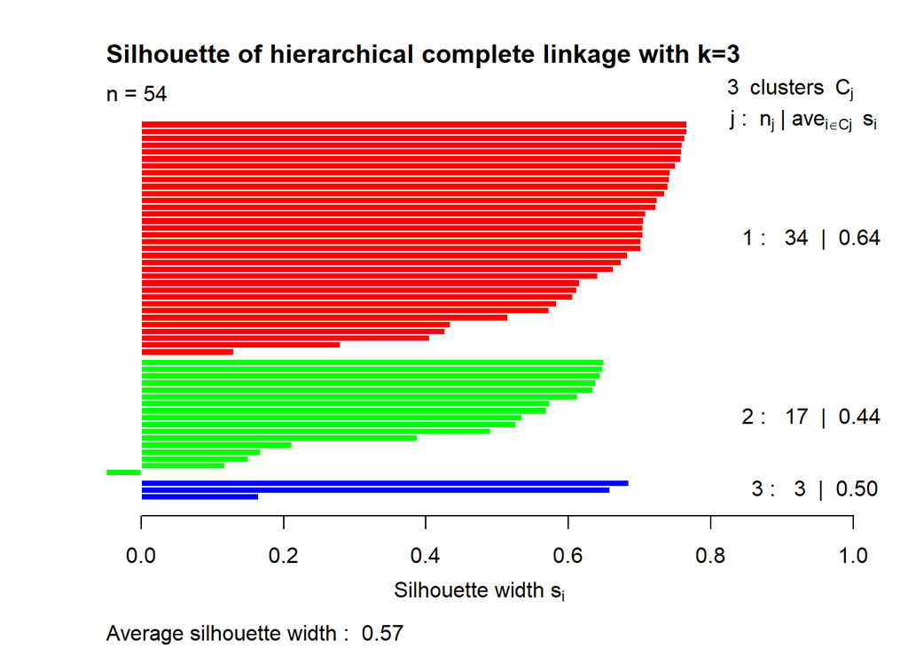

```r
####   silhouette value for complete linkage for k=2
Silhclcompletek3 <- silhouette(cutree(complete_linkage_track,k=3),dist(data))
plot(Silhclcompletek3,main = "Silhouette of hierarchical complete linkage with k=3",col = c("red", "green", "blue"))
```

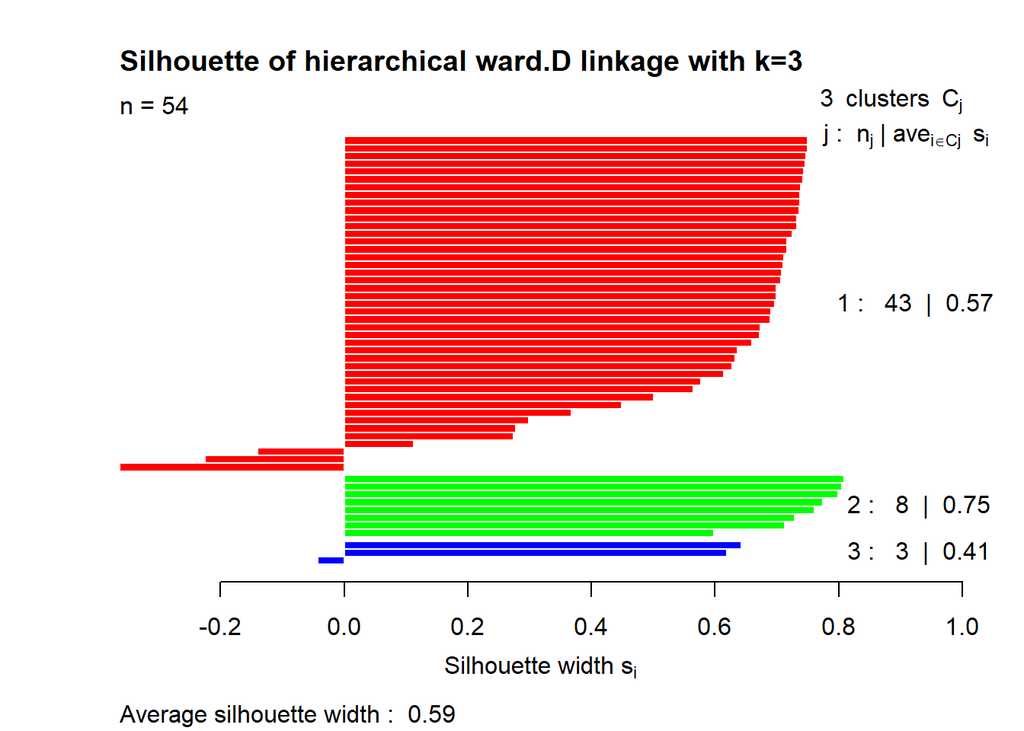

```r
####   silhouette value for Average linkage for k=2
SilhclwardDk3 <- silhouette(cutree(ward_linkage,k=3),dist(data))
plot(SilhclwardDk3,main = "Silhouette of hierarchical ward.D linkage with k=3",col = c("red", "green", "blue"))
```